# 07.Example 1

Modified

We 2026-09-16 13:07

## Given:

Experimental results for the local heat transfer coefficient $h_x$ for flow over a flat plate with an extremely rough surface were found to fit the relation

$$h_x (x) = a x^{-0.1}$$

where $a$ is a coefficient $(\frac{W}{m^{1.9}K})$ and $x (m)$ is the distance from the leading edge of the plate.

Figure 1: Flat Plate

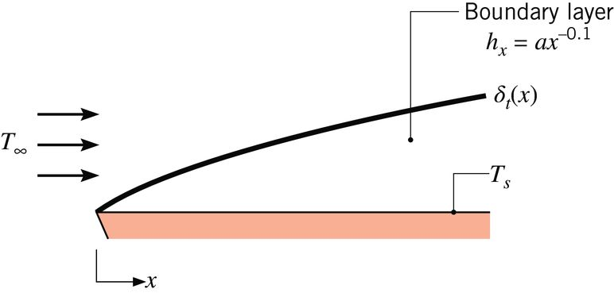

## Required:

Develop an expression for the ratio of the average heat transfer coefficient $\bar{h}_x$ for a plate of length $x$ to the local heat transfer coefficient $h_x$ at $x$. Plot the variation of $h_x$ and $\bar{h}_x$ as a function of $x$.

## Solution:

Start first by importing any needed libraries.

```python
import matplotlib.pyplot as plt
import numpy as np
```

Beginning with the expression for $\bar{h}_x$ for a flat plate,

$$\bar{h}_x\left(x\right) = \frac{1}{x} \int_0^x h_x\left(x\right) dx$$

Entering the given expression for the local convective coefficient shows

$$\bar{h}_x\left(x\right) = \frac{1}{x} \int_0^x a x^{-0.1} dx$$

Since the $a$ term is constant, it may be taken out of the integral as shown by

$$\bar{h}_x\left(x\right) = \frac{a}{x} \int_0^x x^{-0.1} dx$$

At this point integration may be performed. This is shown below.

$$\bar{h}_x\left(x\right) = \frac{a}{x} \left( \frac{x^{0.9}}{0.9}\right)\biggr \rvert_{0}^{x}= \frac{a}{x} \left( \frac{x^{0.9}}{0.9}\right)$$

Simplifying shows

$$\bar{h}_x\left(x\right) = 1.\bar{1} a x^{-0.1}$$
Referring to the given expression for the local convective coefficient $h_x$ shows that the average convective coefficient may be expressed as

Answer: $\bar{h}_x\left(x\right) = 1.\bar{1} h_x\left(x\right)$

Defining a Python function will be a useful way to plot these functions. A Python function for both $h_x$ and $\bar{h}_x$ are defined below. Note the $a$ term is omitted. This is intentional. The $a$ is simply a scaling term and the ordinate axis ($y$ axis) will be put in terms of $a$ so that a single plot may be created to represent any $a$ value.

```python
def h_xFunc(x):
    return x**(-0.1)

def hb_xFunc(x):
    return (1/0.9)*h_xFunc(x)
```

The plotting values for $x$ and the $h$ terms will be created using [Numpy’s](https://docs.scipy.org/doc/numpy/index.html) linspace. This is shown below.

```python
x = np.linspace(0.1, 4, 100) # In meters

h_x = h_xFunc(x)    # In W/(m^2*K)
hb_x = hb_xFunc(x)  # in W/(m^2*K)
```

The plotting handle may now be created and plotting elements added to the plot. This is shown below.

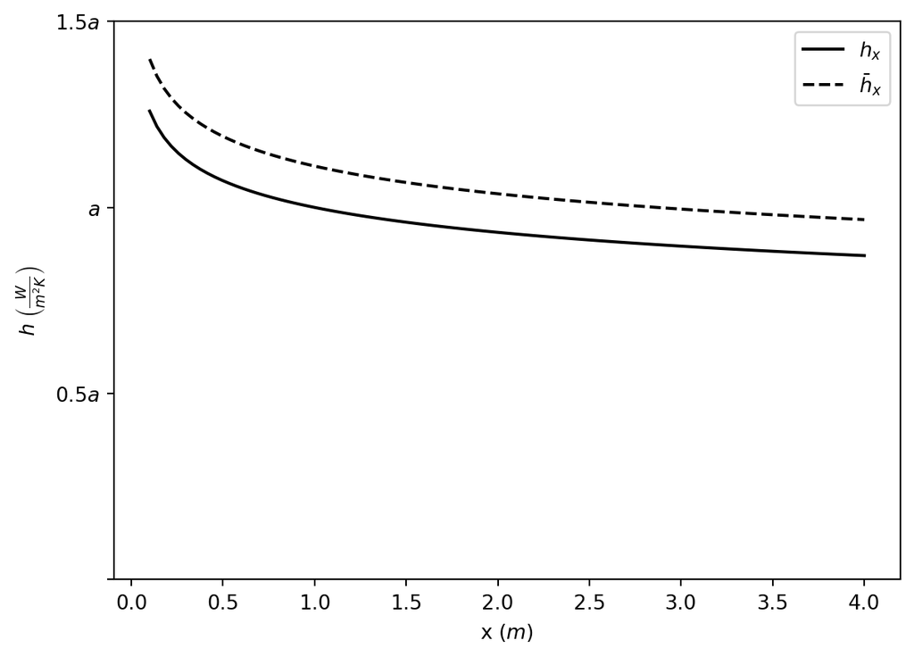

```python
fig, ax=plt.subplots(1, 1)

ax.plot(x, h_x, color = 'k', label = '$h_x$')
ax.plot(x, hb_x, color = 'k', linestyle = 'dashed', label = '$\\bar{h}_x$')

ax.set_xlabel('x $\\left(m\\right)$')
ax.set_ylabel('$h\\ \\left( \\frac{W}{m^2 K}\\right)$')

ax.set_yticks([0, 0.5, 1, 1.5])
ax.set_yticklabels(['', '$0.5a$', '$a$', '$1.5a$'])

ax.legend()

plt.show()
```